# Introdução à Análise de Dados com Python

**Fernando Sola Pereira**

# Tipos de Dados: em relação ao conteúdo

- Número Inteiro: 1, 2, 3
- Número Real, Decimal, Ponto Flutuante: 1.2, 1.33, 10.15
- Binário, Booleano, Lógico:
- Caractere, String, Texto, Categórico: "Fernando", "Brasília", "CGU", "DAS-3"

# Tipos de Dados: em relação ao conteúdo

| DAS | IDADE |
| --- | --- |
| 1 | 33 |
| 2 | 29 |
| 3 | 31 |
| 5 | 50 |
| 4 | 39 |

Tipo de Dados: Numérico para DAS e Idade. Algum problema nisso?

DAS 3 é 3x mai importante que DAS 1?

Dados numéricos nem sempre pode ser tratado ou mantido como numérico.

# Tipos de Dados: em relação à organização

- Estruturado
  - Bancos de dados, arquivos delimitados, arquivos posicionais, excel ...
- Semi-estruturado
  - Json, Html, Xml
- Não-estruturado
  - Imagens, Textos, Vídeos

# Tipos de Análise de Dados

- Descritiva
- Exploratória
- Inferencial
- Preditiva
- Causal
- Mecanicista

## Análise Descritiva

Objetivo: descrever um conjunto de dados

- Média: $$\overline{x} = \frac{\sum_{x_i}}{n}$$
- Moda: mais frequente
- Mediana: divide os dados ordenados em dois
- Variância e Desvio Padrão

### Uma ideia de como os dados se distribuem e seus possíveis outliers?

- Boxplot

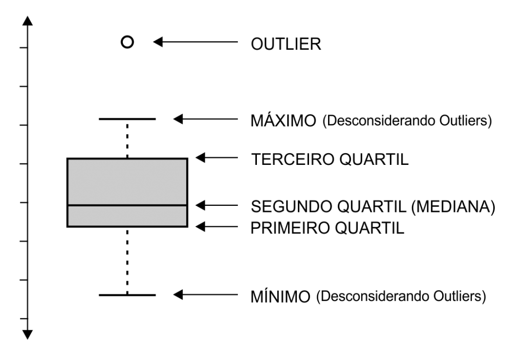

### Apenas sumarização dos dados é suficiente?

- Quarteto de Anscombe

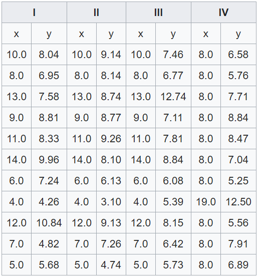

- estatísticas descritivas simples são quase idênticas nos quatro datasets

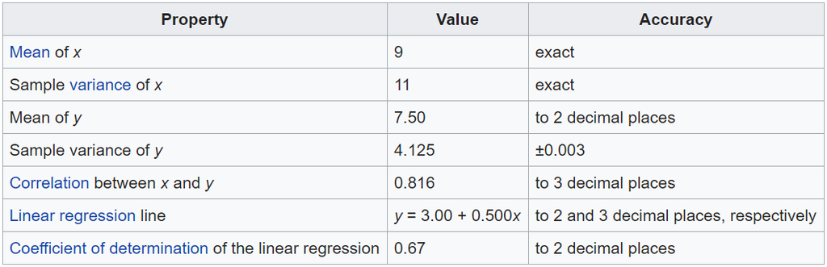

- a representação gráfica é completamente diferente

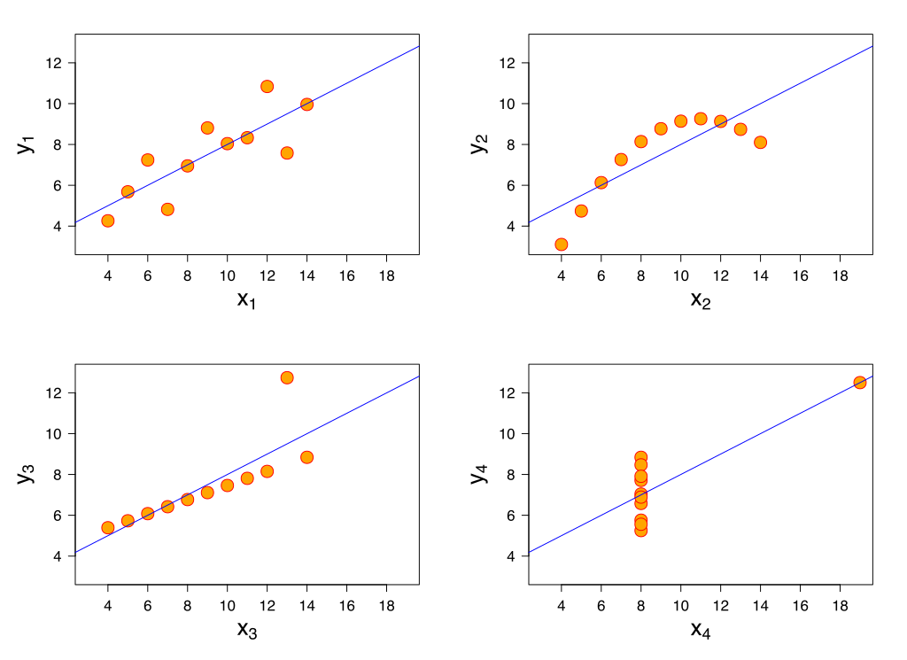

## Análise Exploratória

Objetivo: Encontrar relações/padrões antes desconhecidos

- analisar entendimento prévio
- abrir novos caminhos ou estratégias
- gráficos
- análise univariada e multivariada (relações entre variáveis)

**Isoladamente não deve ser utilizada para generalizar ou prever**

## Análise Inferencial

Objetivo: utilizar uma amostra para generalizar ou dizer algo sobre uma população.

- Testes de Hipótese
- Intervalos de Confiança
- Alguns modelos estatísticos (regressão linear, logística, ...)

Ex: pesquisas eleitorais para saber o resultado de uma eleição com uma determinada margem de erro

## Análise Preditiva

Objetivo: Usar algumas características de algum objeto para prever outras.

- Machine learning

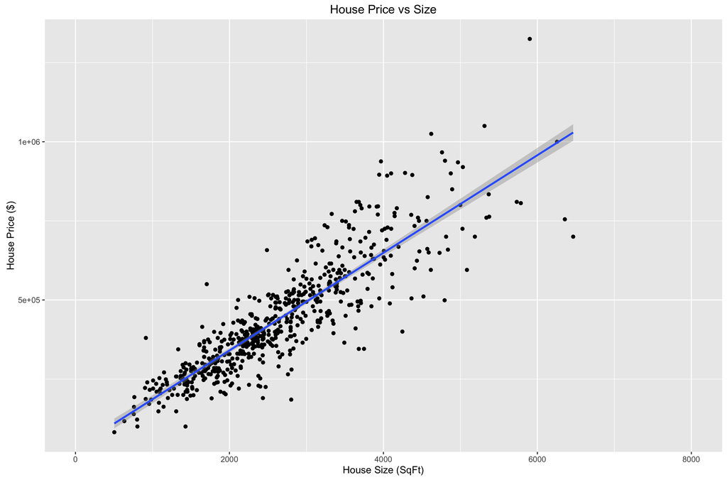

## Análise Causal

Objetivo: o que acontece com uma variável quando você altera outra

- efeito médio pode não ser aplicado a um indivíduo
- Exemplo: Teste A/B. Aumento de cliques em propagandas após uma mudança de layout no site.

## Análise Mecanicista

Objetivo: Entender as exatas mudanças em variáveis que levam a mudanças em outras. Normalmente conjunto determinístico de equações. (Engenharia, Física).

- Exemplo: Simuladores; Análise de pavimentos em rodovias.

# Análise de Dados na Prática

- Tipos de dados estão corretos?
- Existem valores faltantes? Nulos? Vazios?
- Dados estão padronizados? Limpos (Masculino, Masc, F, Feminino)
- Valores são coerentes para os campos? (Idade -20, 190)
- Existem outliers? Como devo tratar?
- Como extraio valores de textos livres?
- O dataset está em formato adequado?
- Posso complementar meu dataset com informções extraídas dele mesmo? (Engenharia de features)

# O que é ciência de dados?

Ciência de dados é o uso conjunto de técnicas e ferramentas de algumas áreas científicas como Estatística e Ciência da Computação com o objetivo de analisar dados e extrair conhecimento ou insights. Ou seja, não é uma ciência e não é uma nova área do conhecimento, é um processo que começa desde a aquisição dos dados até a entrega de um produto que pode subsidiar decisões.

## Processo de ciência de dados

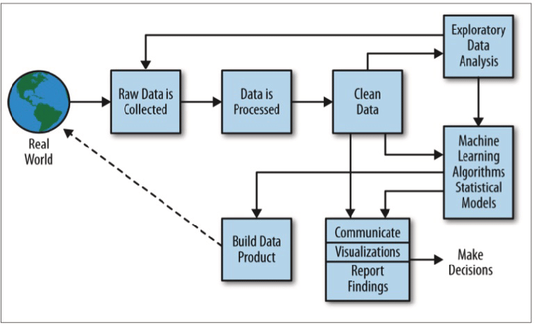

Fonte: [ONEIL & SCHUTT 2014]

## Visão geral de técnicas e ferramentas

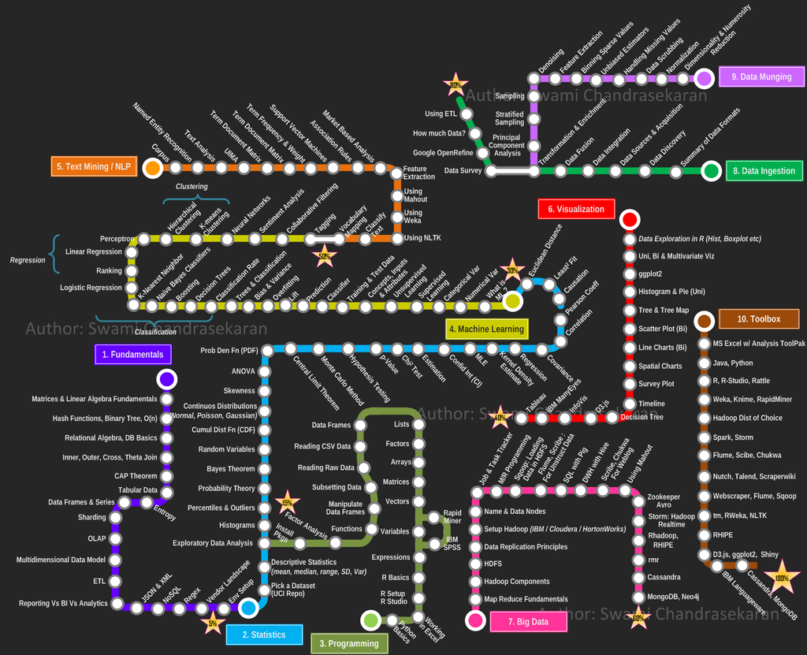

[Abrir Imagem Original](https://miro.medium.com/max/1550/1*NGfYYTNes6WAZyeP2Dyizg.png)

Fonte: [A realidade por trás do Data Science e dos Unicórnios](https://medium.com/data-hackers/a-realidade-por-trás-do-data-science-e-dos-unicórnios-4d947538f104)

# Objetivo do curso

- Apresentar uma visão geral sobre análise de dados e contextualizar dentro da ciência de dados
- Desenvolver um pouco os skils de:
  - programação
  - coleta de dados
  - limpeza de dados
  - transformação de dados
  - análise descritiva
  - análise exploratória
  - visualização de dados

# Leituras Recomendadas

- Apresentação do Ricardo (docs/AD-2018-Conceitos.pdf)
- The Elements of Data Analytic Style: A guide for people who want to analyze data (docs/datastyle.pdf)

**Material produzido para o curso**:

- Introdução à Análise de Dados com Python

**Autor**:

- Fernando Sola Pereira

**Revisão**:

- 1.2